GA report

Date: May 22, 2022

Abstract

This simulation project is aiming on evolving random noise into creatures in a 2-d virtual environment

while trying to minimum human’s predene and intervention. Genetic algorithm is used to generate

and evolve the brain’s neural system of the creature, which controls all the individual’s behaviors.

Creatures are allowed to interact with environment and each other, which leads to the natural selection

Keywords:

1 Introduction

2 Related Works

3 Methods

3.1 Virtual Environment

3.2 Creature Control

3.2.1 Brain Structure

Sensor

Inner Neural

Activator

Link Rule

3.2.2 Represent Brain

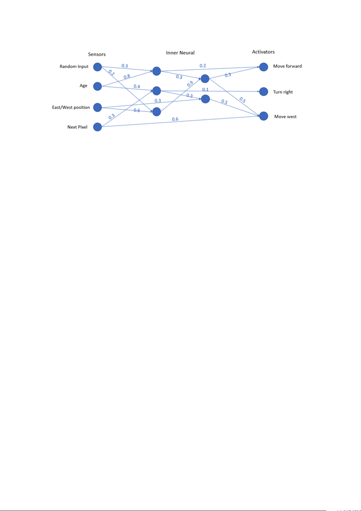

3.3 Selection Strategy

3.3.1 Synchronous

3.3.2 Asynchronous

3.3.3 Adversarial Selection

3.4 Reproduction and Mutation

4 Results

4.2 Cell Behavior in Adversarial Simulation

Initial Stage

Ediacaran Period

Middle Stage

Stable Stage

[figure not shown]

5 conclusion

6 Future Work

References

   Primerpython     https://github.com/Helpsypoo/primerpython

    biosim4     https : / / github . com / davidrmiller / biosim4

   The Life Engine     https://github.com/MaxRobinsonTheGreat/LifeEngine

       Proceedings of the 21st annual conference on Computer graphics and inter-

active techniques - SIGGRAPH ’94   10.1145/192161.192167